# AXCESSR Conceptualisation

Author

Tilabo Williamson, Caitlin Buenk & Jürgen Becker (Project Lead) - AX Consult Group

Published

2026-04-23

[figure not shown]

# Introduction

Three parties make every student-funding decision: the student, the institution, and the lender. None of them have the data they need to make it well.

In South Africa, roughly 68 000 “missing middle” students sit in the gap between government bursaries (capped at R350,000 household income) and self-funding affordability - and even after recent policy reforms introducing loan funding for the R350K–R600K income band, only about 47% currently receive any support.[^1] South Africa’s first-year university dropout rate sits at 35 – 40%, with financial exclusion and poor programmatic fit consistently identified as primary drivers.[^2] In the United States, the picture is no better: as of December 2025, approximately $180 billion in federal student loans were in default across 7.7 million borrowers, and 29.5% of the active portfolio was delinquent by dollar balance - more than double the pre-pandemic rate.[^3] These outcomes share a common cause: students, higher education institutions, and lenders are all making high-stakes decisions on incomplete and asymmetric information about who will succeed academically and financially.

AXCESSR addresses this by manufacturing data symmetry across all three parties. It is a psychometric assessment and decision platform that produces a shared, validated signal - derived from four measured psychological domains (personality, values, emotion traits, and emotion states) - that students, Higher Education Institutions (HEIs), and lenders can each act on. Students get evidence of programmatic and career fit before committing time and capital. Institutions get completion-likelihood signals beyond academic records. Lenders get repayment-behaviour predictors that work for thin-file applicants without an established credit history. The same psychometric data point underwrites all three decisions, replacing the fragmented and asymmetric inputs each party currently relies on.

*AXCESSR Overview*

[figure not shown]

AXCESSR sits at the centre of the funding ecosystem, generating tailored information for each stakeholder it serves. The *applicant* receives a personalised behavioural risk profile. *Lenders* and *HEIs* receive a structured risk report, giving them the psychometric signal they need to make confident placement and funding decisions on candidates who would otherwise be invisible to conventional screening. Lastly, a more technical and clinical-grade report is generated and kept on file.

## Purpose of the Assessment

The primary objectives of AXCESSR are to:

- Improve access to student funding for academically eligible candidates without an established credit or academic record
- Match students to programmes where they are likely to succeed
- Provide higher education institutions with completion-likelihood signals beyond academic records
- Provide lenders with repayment-behaviour predictors validated for thin-file populations
- Support risk assessment, underwriting, and portfolio management for funders

## How AXCESSR was built

AXCESSR was not built with data science as an afterthought. From initial construct mapping and **conceptualisation** through to **data validity** and candidate screening, and into **UX research**, every stage of development was data-informed. The pipeline below illustrates how each phase fed into the next.

*AXCESSR Development Pipeline*

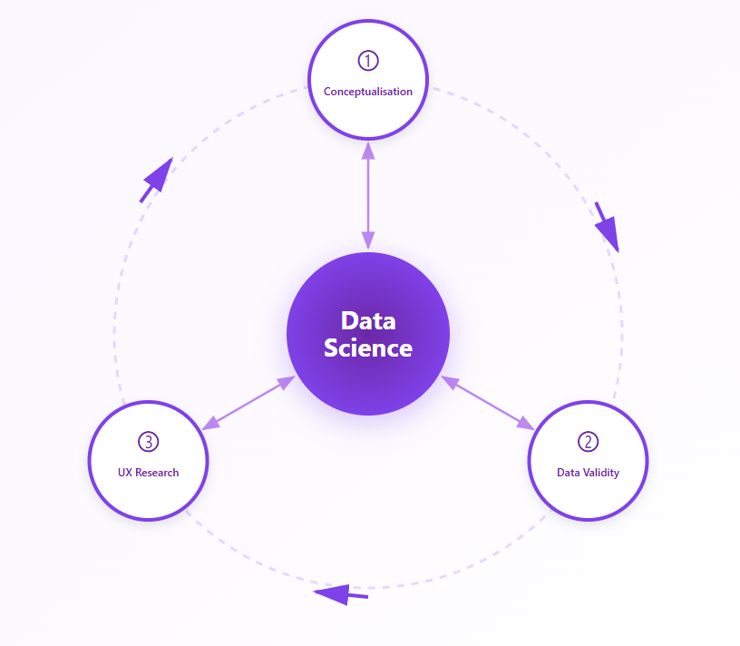

The pipeline above illustrates the three core development phases of AXCESSR - *conceptualisation*, *validation*, and *UX research* - each producing data that feeds the next, and each iteration of the cycle informing a sharper version of the instrument. This is not a linear build. AXCESSR is designed to evolve: findings from validation reshape the item pool, UX research exposes where the assessment places unnecessary burden, and both inform the decisions that define the next iteration - including the move toward a Computerised Adaptive Testing (CAT) engine that shortens assessment time and reduces respondent load without sacrificing measurement precision.

The first cycle began with construct mapping and item generation, grounded in established psychometric reference scales. Validation followed - reliability analyses, IRT diagnostics, and the removal of 41 problematic items refined the instrument from 247 to 206 items. UX research then surfaced the real-world experience of respondents, closing the loop and opening the next one. Each phase fed the next, with all phases being led by data.

# Conceptualisation

Figma Conceptualisation Presentation Link -> https://www.figma.com/deck/BWVGJvpN2KeOfJEtiEwUf5

## The problem

AXCESSR is a psychometric-based credit risk assessment platform designed to extend financial access to individuals overlooked by traditional credit origination methods - either due to limited credit history or an overestimation of risk based on conventional metrics. Rather than relying on historical financial data, the platform evaluates creditworthiness through the measurement of stable personal dispositions shown to predict financial decision-making and repayment behaviour.

*The Funding Access Gap*

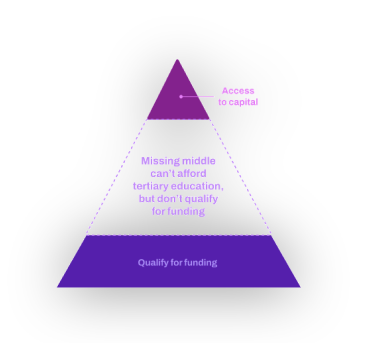

The platform targets two primary markets: the student loan market, where millions of academically eligible students lack access to funding, and the broader personal credit market, where thin-file and credit-invisible individuals remain underserved. Psychometric scores can be generated for any candidate irrespective of formal credit history and, because scores are user-generated, they are broadly compliant with consumer privacy regulations.

## Assessment Architecture

Four core psychological domains were identified through a review of the behavioural science literature as the constructs most predictive of real-world financial and educational outcomes:

- **Personality** — stable trait dispositions that shape how individuals behave across contexts
- **Values** — motivational orientations that drive long-term decision-making and goal alignment
- **Emotional Traits** — enduring patterns of emotional responding, including impulsivity and self-regulation
- **Emotional States** — situational affective tendencies such as stress reactivity and boredom proneness

*AXCESSR Structure*

[figure not shown]

With the domain structure established theoretically, the next challenge was operationalisation - translating abstract constructs into measurable, defensible items

## Item Development

Item development drew on a structured review of established psychometric frameworks, adapting content from validated instruments across each risk domain. Source instruments included the International Personality Item Pool (IPIP), the HEXACO Personality Inventory, the Schwartz Value Survey (SVS), the Trait Emotional Intelligence Questionnaire (TEIQue), the Short Dark Triad (SD3), the Edwards Compulsive Buying Scale (ECBS), the Barratt Impulsivity Scale, the Sensation Seeking Scale, and the UPPS Impulsive Behaviour Scale.

The below figure illustrates the diverse psychological frameworks and reputable assessment scales that were integrated to develop the AXCESSR item pool, highlighting the foundational instruments that informed its construction

*Frameworks Underpinning the AXCESSR Item Pool Development*

[figure not shown]

Every item in the AXCESSR pool traces back to a documented psychological construct. Items were not written opportunistically - each one was derived from a defined theoretical basis and subjected to a structured development pipeline before inclusion in the instrument.

*Item Development Structure*

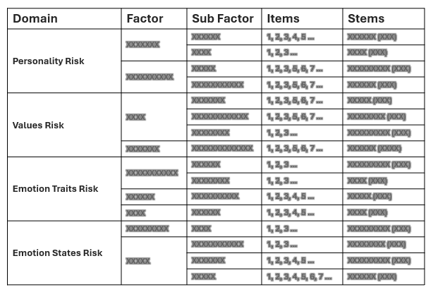

Each item was engineered to measure a specific construct dimension with precision. The example below illustrates the structural components of a single AXCESSR.

*Item Anatomy*

[output not shown]

## From Score to Decision

Item responses aggregate upward through the hierarchy, producing an actionable output at each level.

Item responses → Subfactor score → Factor score → Domain score → Risk profile